# Lab9_McMullen

Jared McMullen

2021-12-05

**Library Packages**

```r
library(tidyverse)
library(tidymodels)
library(rpart.plot)
library(discrim)
library(baguette)
library(janitor)
library(DT)
```

# Dataset 1: Mushrooms

```r
mushrooms <- read_csv("https://www.dropbox.com/s/jk5q3dq1u63ey1e/mushrooms.csv?dl=1",
                      col_types = str_c(rep("c", 23), collapse = ""))
datatable(mushrooms)
```

|  | class | cap-shape | cap-surface | cap-color | bruises | odor | gill-attachment | gill-spacing | gill-size | gill-color | stalk-shape | stalk-root | stalk-surface-above-ring | stalk-surface-below-ring | stalk-color-above-ring | stalk-color-below-ring | veil-type | veil-color | ring-number | ring-type | spore-print-color | population | habitat |
| --- | --- | --- | --- | --- | --- | --- | --- | --- | --- | --- | --- | --- | --- | --- | --- | --- | --- | --- | --- | --- | --- | --- | --- |
| 1 | p | x | s | n | t | p | f | c | n | k | e | e | s | s | w | w | p | w | o | p | k | s | u |
| 2 | e | x | s | y | t | a | f | c | b | k | e | c | s | s | w | w | p | w | o | p | n | n | g |
| 3 | e | b | s | w | t | l | f | c | b | n | e | c | s | s | w | w | p | w | o | p | n | n | m |
| 4 | p | x | y | w | t | p | f | c | n | n | e | e | s | s | w | w | p | w | o | p | k | s | u |
| 5 | e | x | s | g | f | n | f | w | b | k | t | e | s | s | w | w | p | w | o | e | n | a | g |
| 6 | e | x | y | y | t | a | f | c | b | n | e | c | s | s | w | w | p | w | o | p | k | n | g |
| 7 | e | b | s | w | t | a | f | c | b | g | e | c | s | s | w | w | p | w | o | p | k | n | m |
| 8 | e | b | y | w | t | l | f | c | b | n | e | c | s | s | w | w | p | w | o | p | n | s | m |
| 9 | p | x | y | w | t | p | f | c | n | p | e | e | s | s | w | w | p | w | o | p | k | v | g |
| 10 | e | b | s | y | t | a | f | c | b | g | e | c | s | s | w | w | p | w | o | p | k | s | m |

[output cut: 8114 more lines]

```r
mushrooms <- mushrooms %>%
    janitor::clean_names()
```

# Part One: A perfect tree

```r
mushroom_recipe <- recipe(class ~ .,
                     data = mushrooms)

tree_mod <- decision_tree() %>%
  set_engine("rpart") %>%
  set_mode("classification")

tree_wflow <- workflow() %>%
  add_recipe(mushroom_recipe) %>%
  add_model(tree_mod) %>%
  fit(mushrooms)
#Determine that accuracy is nearly 100 percent!

tree_fitted <- tree_wflow %>%
   pull_workflow_fit()
```

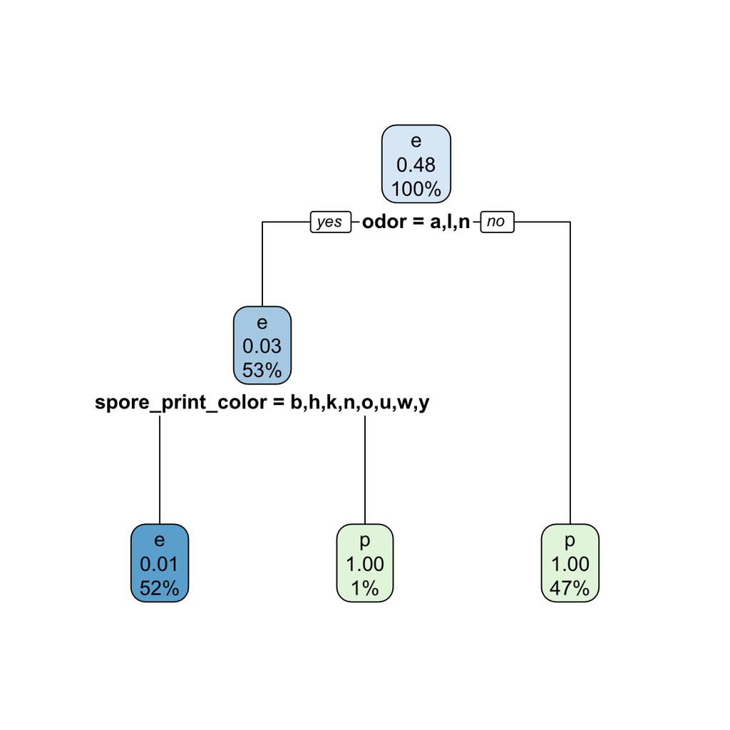

```r
rpart.plot(tree_fitted$fit)
```

**Nature Guide**

# Part Two: … or is it?

## Q1: Cross validation

```r
mushrooms_cvs <- vfold_cv(mushrooms, v = 5)

mushroom_recipe <- recipe(class ~ .,
                     data = mushrooms)

tree_wflow <- workflow() %>%
  add_recipe(mushroom_recipe) %>%
  add_model(tree_mod)

tree_fit <- tree_wflow %>%
  fit_resamples(mushrooms_cvs)

tree_fit %>%
  collect_metrics()
```

```
## # A tibble: 2 × 6
##   .metric  .estimator  mean     n  std_err .config
##   <chr>    <chr>      <dbl> <int>    <dbl> <chr>
## 1 accuracy binary     0.994     5 0.000925 Preprocessor1_Model1
## 2 roc_auc  binary     0.994     5 0.000954 Preprocessor1_Model1
```

The classification rules we learned in Part One probably apply to all mushrooms because this model is not overfit, but it does have an extremely high accuracy of 99.4% when cross-validated.

## Q2: Bagging

```r
mushrooms_twoplus <- mushrooms %>%
  select(-`gill_attachment`, -`veil_type`)

mushrooms_twoplus_cvs <- vfold_cv(mushrooms_twoplus, v = 5)

tree_spec <- bag_tree() %>%
  set_engine("rpart", times = 25) %>%
  set_mode("classification")

mushroom_recipe <- recipe(class ~ .,
                     data = mushrooms_twoplus)

bag_tree_wflow <- workflow() %>%
  add_recipe(mushroom_recipe) %>%
  add_model(tree_spec)

tree_fit <- bag_tree_wflow %>%
  fit_resamples(mushrooms_twoplus_cvs)

tree_fit %>%
  collect_metrics()
```

```
## # A tibble: 2 × 6
##   .metric  .estimator  mean     n std_err .config
##   <chr>    <chr>      <dbl> <int>   <dbl> <chr>
## 1 accuracy binary         1     5       0 Preprocessor1_Model1
## 2 roc_auc  binary         1     5       0 Preprocessor1_Model1
```

This model is overfit because we see the accuracy and roc_auc as exactly 1 so it would not be successful predicting on new data.

## Q3: Random Forests

```r
library(ranger)
rand_forest_spec <- rand_forest(mtry = tune(), trees = tune(), min_n = tune()) %>%
set_engine("ranger") %>%
set_mode("classification")

rf_wflow <- workflow() %>%
  add_recipe(mushroom_recipe) %>%
  add_model(rand_forest_spec)

rf_grid_search <-
  tune_grid(
    rf_wflow,
    resamples = mushrooms_cvs,
    grid = 20)
```

```
## i Creating pre-processing data to finalize unknown parameter: mtry
```

```r
#Find best
rf_grid_search %>%
  collect_metrics()
```

```
## # A tibble: 40 × 9
##     mtry trees min_n .metric  .estimator  mean     n std_err .config
##    <int> <int> <int> <chr>    <chr>      <dbl> <int>   <dbl> <chr>
##  1    12   310    36 accuracy binary         1     5       0 Preprocessor1_Mode…
##  2    12   310    36 roc_auc  binary         1     5       0 Preprocessor1_Mode…
##  3     4  1345     9 accuracy binary         1     5       0 Preprocessor1_Mode…
##  4     4  1345     9 roc_auc  binary         1     5       0 Preprocessor1_Mode…
##  5    20   704    27 accuracy binary         1     5       0 Preprocessor1_Mode…
##  6    20   704    27 roc_auc  binary         1     5       0 Preprocessor1_Mode…
##  7    11  1202    19 accuracy binary         1     5       0 Preprocessor1_Mode…
##  8    11  1202    19 roc_auc  binary         1     5       0 Preprocessor1_Mode…
##  9    10   518    34 accuracy binary         1     5       0 Preprocessor1_Mode…
## 10    10   518    34 roc_auc  binary         1     5       0 Preprocessor1_Mode…
## # … with 30 more rows
```

```r
rf_grid_search %>%
  collect_metrics() %>%
  filter(.metric == "accuracy") %>%
  slice_max(mean)
```

```
## # A tibble: 20 × 9
##     mtry trees min_n .metric  .estimator  mean     n std_err .config
##    <int> <int> <int> <chr>    <chr>      <dbl> <int>   <dbl> <chr>
##  1    12   310    36 accuracy binary         1     5       0 Preprocessor1_Mode…
##  2     4  1345     9 accuracy binary         1     5       0 Preprocessor1_Mode…
##  3    20   704    27 accuracy binary         1     5       0 Preprocessor1_Mode…
##  4    11  1202    19 accuracy binary         1     5       0 Preprocessor1_Mode…
##  5    10   518    34 accuracy binary         1     5       0 Preprocessor1_Mode…
##  6     6  1776    34 accuracy binary         1     5       0 Preprocessor1_Mode…
##  7     8  1135    13 accuracy binary         1     5       0 Preprocessor1_Mode…
##  8    15   443    10 accuracy binary         1     5       0 Preprocessor1_Mode…
##  9    16   956     6 accuracy binary         1     5       0 Preprocessor1_Mode…
## 10    18  1415    28 accuracy binary         1     5       0 Preprocessor1_Mode…
## 11    16    21     3 accuracy binary         1     5       0 Preprocessor1_Mode…
## 12     2   690    16 accuracy binary         1     5       0 Preprocessor1_Mode…
## 13     6   843     6 accuracy binary         1     5       0 Preprocessor1_Mode…
## 14    19  1577    15 accuracy binary         1     5       0 Preprocessor1_Mode…
## 15    13  1825    40 accuracy binary         1     5       0 Preprocessor1_Mode…
## 16     2  1043    22 accuracy binary         1     5       0 Preprocessor1_Mode…
## 17     8  1614    30 accuracy binary         1     5       0 Preprocessor1_Mode…
## 18    14  1924    20 accuracy binary         1     5       0 Preprocessor1_Mode…
## 19     9   134    24 accuracy binary         1     5       0 Preprocessor1_Mode…
## 20     4   203    31 accuracy binary         1     5       0 Preprocessor1_Mode…
```

This model is overfit because the accuracy is 1 and it would not be successful predicting on new data.

## Q4: Neural Networks

```r
nn_grid <- grid_regular(
  hidden_units(c(2, 12)),
  penalty(c(-5, 0)),
  levels = 3)

nn_mod <- mlp(
  hidden_units = tune(),
  penalty = tune(),
  epochs = 100,
  activation = "linear"
  ) %>%
  set_engine("nnet") %>%
  set_mode("classification")

nn_wflow <- workflow() %>%
  add_recipe(mushroom_recipe) %>%
  add_model(nn_mod)

nn_grid_search <-
  tune_grid(
    nn_wflow,
    resamples = mushrooms_twoplus_cvs,
    grid = nn_grid
  )
```

[output not shown]

[output not shown]

[output not shown]

[output not shown]

[output not shown]

[output not shown]

[output not shown]

[output not shown]

[output not shown]

[output not shown]

[output not shown]

[output not shown]

[output not shown]

[output not shown]

[output not shown]

```r
nn_grid_search %>%
  collect_metrics()
```

```
## # A tibble: 12 × 8
##    hidden_units penalty .metric  .estimator  mean     n std_err .config
##           <int>   <dbl> <chr>    <chr>      <dbl> <int>   <dbl> <chr>
##  1            2 0.00001 accuracy binary     0.998     5 0.00172 Preprocessor1_M…
##  2            2 0.00001 roc_auc  binary     0.997     5 0.00271 Preprocessor1_M…
##  3            7 0.00001 accuracy binary     1         5 0       Preprocessor1_M…
##  4            7 0.00001 roc_auc  binary     1         5 0       Preprocessor1_M…
##  5            2 0.00316 accuracy binary     0.995     5 0.00269 Preprocessor1_M…
##  6            2 0.00316 roc_auc  binary     0.995     5 0.00483 Preprocessor1_M…
##  7            7 0.00316 accuracy binary     1         5 0       Preprocessor1_M…
##  8            7 0.00316 roc_auc  binary     1         5 0       Preprocessor1_M…
##  9            2 1       accuracy binary     1         5 0       Preprocessor1_M…
## 10            2 1       roc_auc  binary     1         5 0       Preprocessor1_M…
## 11            7 1       accuracy binary     1         5 0       Preprocessor1_M…
## 12            7 1       roc_auc  binary     1         5 0       Preprocessor1_M…
```

```r
nn_grid_search %>%
  collect_metrics() %>%
  filter(.metric == "accuracy") %>%
  slice_max(mean)
```

```
## # A tibble: 4 × 8
##   hidden_units penalty .metric  .estimator  mean     n std_err .config
##          <int>   <dbl> <chr>    <chr>      <dbl> <int>   <dbl> <chr>
## 1            7 0.00001 accuracy binary         1     5       0 Preprocessor1_Mo…
## 2            7 0.00316 accuracy binary         1     5       0 Preprocessor1_Mo…
## 3            2 1       accuracy binary         1     5       0 Preprocessor1_Mo…
## 4            7 1       accuracy binary         1     5       0 Preprocessor1_Mo…
```

This model is overfit because the accuracy is 1 and it would not be successful predicting on new data.

# Part Three: Logistic Regression

We used odor and spore_print_color as out indicator variables because our tree outputted these as the two most important variables in predicting poisonous mushrooms. Given that our logistic regression model with only these two variables was still extremely high in accuracy, our conclusion that these are two of the most important variables in considering the poison level of the mushrooms is supported.

```r
log_mod <- logistic_reg() %>%
  set_mode("classification") %>%
  set_engine("glm")

mushroom_recipe <- recipe(class ~ odor + spore_print_color,
                     data = mushrooms_twoplus)

log_wflow <- workflow() %>%
  add_recipe(mushroom_recipe) %>%
  add_model(log_mod)

tree_fit <- log_wflow %>%
  fit_resamples(mushrooms_twoplus_cvs)
```

```
## ! Fold1: preprocessor 1/1, model 1/1: glm.fit: fitted probabilities numerically 0...
```

```
## ! Fold2: preprocessor 1/1, model 1/1: glm.fit: fitted probabilities numerically 0...
```

```
## ! Fold3: preprocessor 1/1, model 1/1: glm.fit: fitted probabilities numerically 0...
```

```
## ! Fold4: preprocessor 1/1, model 1/1: glm.fit: fitted probabilities numerically 0...
```

```
## ! Fold5: preprocessor 1/1, model 1/1: glm.fit: fitted probabilities numerically 0...
```

```r
tree_fit %>%
  collect_metrics()
```

```
## # A tibble: 2 × 6
##   .metric  .estimator  mean     n   std_err .config
##   <chr>    <chr>      <dbl> <int>     <dbl> <chr>
## 1 accuracy binary     0.994     5 0.000718  Preprocessor1_Model1
## 2 roc_auc  binary     0.999     5 0.0000964 Preprocessor1_Model1
```

# Dataset 2: Telecom Customers

```r
tele <- read_csv("https://www.dropbox.com/s/9dymy30v394ud8h/Telecust1.csv?dl=1")
datatable(tele)
```

|  | region | tenure | age | income | marital | address | ed | employ | retire | gender | reside | custcat |
| --- | --- | --- | --- | --- | --- | --- | --- | --- | --- | --- | --- | --- |
| 1 | 2 | 13 | 44 | 64 | 1 | 9 | 4 | 5 | 0 | 0 | 2 | A |
| 2 | 3 | 11 | 33 | 136 | 1 | 7 | 5 | 5 | 0 | 0 | 6 | D |
| 3 | 3 | 68 | 52 | 116 | 1 | 24 | 1 | 29 | 0 | 1 | 2 | C |
| 4 | 2 | 33 | 33 | 33 | 0 | 12 | 2 | 0 | 0 | 1 | 1 | A |
| 5 | 2 | 23 | 30 | 30 | 1 | 9 | 1 | 2 | 0 | 0 | 4 | C |
| 6 | 2 | 41 | 39 | 78 | 0 | 17 | 2 | 16 | 0 | 1 | 1 | C |
| 7 | 3 | 45 | 22 | 19 | 1 | 2 | 2 | 4 | 0 | 1 | 5 | B |
| 8 | 2 | 38 | 35 | 76 | 0 | 5 | 2 | 10 | 0 | 0 | 3 | D |
| 9 | 3 | 45 | 59 | 166 | 1 | 7 | 4 | 31 | 0 | 0 | 5 | C |
| 10 | 1 | 68 | 41 | 72 | 1 | 21 | 1 | 22 | 0 | 0 | 3 | B |

[output cut: 990 more lines]

```r
tele <- tele %>%
  mutate(
    region = factor(region),
    marital = factor(marital),
    gender =factor(gender),
    retire = factor(retire),
    custcat = factor(custcat)
  )
tele_cvs <- vfold_cv(tele, v = 5)
```

## Welcome to the Summary of Work

```r
tele_recipe <- recipe(custcat ~ .,
                     data = tele)
tree_mod <- decision_tree() %>%
  set_engine("rpart") %>%
  set_mode("classification")

tree_wflow <- workflow() %>%
  add_recipe(tele_recipe) %>%
  add_model(tree_mod) %>%
  fit(tele)

tree_fitted <- tree_wflow %>%
   pull_workflow_fit()
```

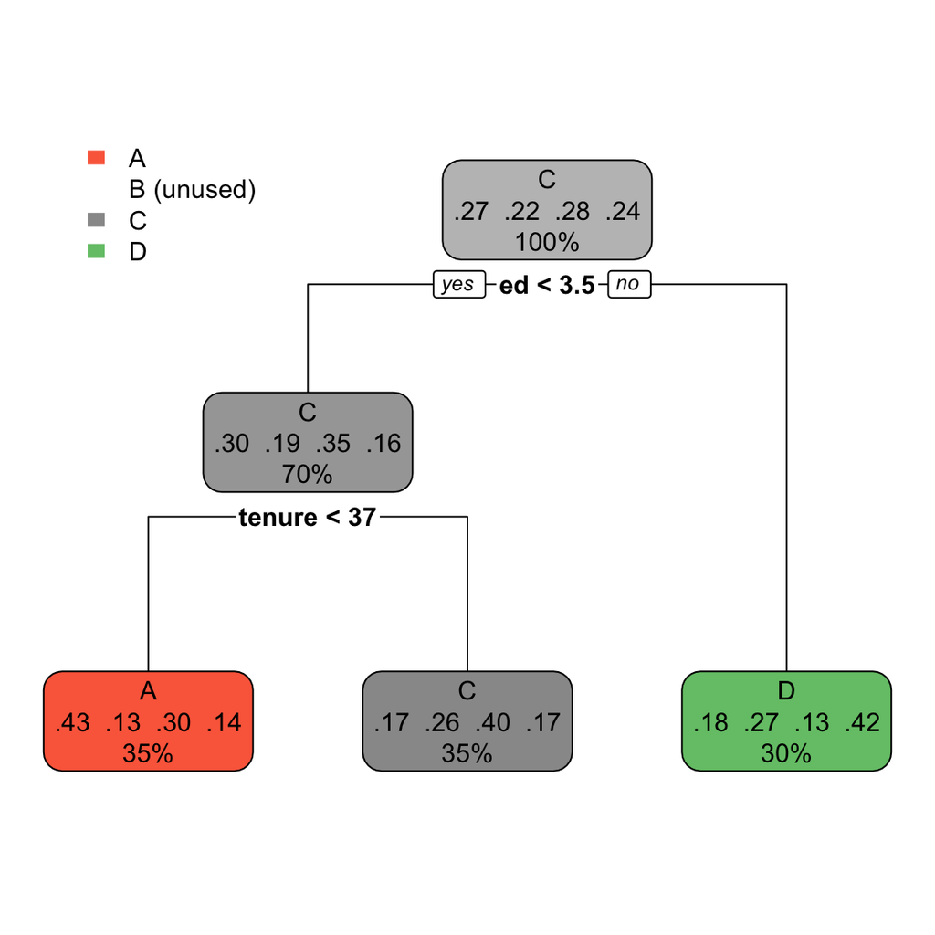

```r
rpart.plot(tree_fitted$fit)
```

```r
tele_recipe <- recipe(custcat ~ ed + tenure,
                     data = tele)

tree_wflow <- workflow() %>%
  add_recipe(tele_recipe) %>%
  add_model(tree_mod)

fit_decisiontree <- tree_wflow %>%
  fit_resamples(tele_cvs)

fit_decisiontree %>% collect_metrics()
```

```
## # A tibble: 2 × 6
##   .metric  .estimator  mean     n std_err .config
##   <chr>    <chr>      <dbl> <int>   <dbl> <chr>
## 1 accuracy multiclass 0.407     5  0.0201 Preprocessor1_Model1
## 2 roc_auc  hand_till  0.637     5  0.0108 Preprocessor1_Model1
```

```r
#Gini Index
tele %>%
  bind_cols(
    predict(tree_fitted, tele, type = "prob")
  ) %>%
  gain_capture(truth = custcat,
               .pred_A, .pred_B, .pred_C, .pred_D)
```

```
## # A tibble: 1 × 3
##   .metric      .estimator .estimate
##   <chr>        <chr>          <dbl>
## 1 gain_capture macro          0.275
```

# bagging

```r
bag_spec <- bag_tree() %>%
  set_engine("rpart", times = 25) %>%
  set_mode("classification")

tele_recipe <- recipe(custcat ~ ed + tenure,
                     data = tele)

bag_tree_wflow <- workflow() %>%
  add_recipe(tele_recipe) %>%
  add_model(bag_spec)

tree_fit <- bag_tree_wflow %>%
  fit_resamples(tele_cvs)

tree_fit %>%
  collect_metrics()
```

```
## # A tibble: 2 × 6
##   .metric  .estimator  mean     n std_err .config
##   <chr>    <chr>      <dbl> <int>   <dbl> <chr>
## 1 accuracy multiclass 0.361     5 0.0122  Preprocessor1_Model1
## 2 roc_auc  hand_till  0.624     5 0.00878 Preprocessor1_Model1
```

# NN

```r
nn_grid <- grid_regular(
  hidden_units(c(2, 12)),
  penalty(c(-5, 0)),
  levels = 3)

nn_mod <- mlp(
  hidden_units = tune(),
  penalty = tune(),
  epochs = 100,
  activation = "linear"
  ) %>%
  set_engine("nnet") %>%
  set_mode("classification")

nn_wflow <- workflow() %>%
  add_recipe(tele_recipe) %>%
  add_model(nn_mod)

nn_grid_search <-
  tune_grid(
    nn_wflow,
    resamples = tele_cvs,
    grid = nn_grid
  )
nn_grid_search %>%
  collect_metrics()
```

```
## # A tibble: 18 × 8
##    hidden_units penalty .metric  .estimator  mean     n std_err .config
##           <int>   <dbl> <chr>    <chr>      <dbl> <int>   <dbl> <chr>
##  1            2 0.00001 accuracy multiclass 0.376     5 0.0136  Preprocessor1_M…
##  2            2 0.00001 roc_auc  hand_till  0.677     5 0.0164  Preprocessor1_M…
##  3            7 0.00001 accuracy multiclass 0.385     5 0.00935 Preprocessor1_M…
##  4            7 0.00001 roc_auc  hand_till  0.687     5 0.00968 Preprocessor1_M…
##  5           12 0.00001 accuracy multiclass 0.38      5 0.0167  Preprocessor1_M…
##  6           12 0.00001 roc_auc  hand_till  0.684     5 0.0101  Preprocessor1_M…
##  7            2 0.00316 accuracy multiclass 0.387     5 0.00682 Preprocessor1_M…
##  8            2 0.00316 roc_auc  hand_till  0.693     5 0.00828 Preprocessor1_M…
##  9            7 0.00316 accuracy multiclass 0.378     5 0.00718 Preprocessor1_M…
## 10            7 0.00316 roc_auc  hand_till  0.688     5 0.0100  Preprocessor1_M…
## 11           12 0.00316 accuracy multiclass 0.374     5 0.00485 Preprocessor1_M…
## 12           12 0.00316 roc_auc  hand_till  0.686     5 0.00777 Preprocessor1_M…
## 13            2 1       accuracy multiclass 0.402     5 0.0103  Preprocessor1_M…
## 14            2 1       roc_auc  hand_till  0.695     5 0.00983 Preprocessor1_M…
## 15            7 1       accuracy multiclass 0.392     5 0.00374 Preprocessor1_M…
## 16            7 1       roc_auc  hand_till  0.693     5 0.00922 Preprocessor1_M…
## 17           12 1       accuracy multiclass 0.384     5 0.00620 Preprocessor1_M…
## 18           12 1       roc_auc  hand_till  0.694     5 0.00901 Preprocessor1_M…
```

```r
nn_grid_search %>%
  collect_metrics() %>%
  filter(.metric == "accuracy") %>%
  slice_max(mean)
```

```
## # A tibble: 1 × 8
##   hidden_units penalty .metric  .estimator  mean     n std_err .config
##          <int>   <dbl> <chr>    <chr>      <dbl> <int>   <dbl> <chr>
## 1            2       1 accuracy multiclass 0.402     5  0.0103 Preprocessor1_Mo…
```

The most accurate model is the single decision tree with around 40% accuracy so this is the model I would use to predict the customer category. We tried to add more variables to increase accuracy of our other models but just using ed and tenure proved most accurate with neural network and bagging models, but still less accurate than the single tree model.